# 911CallsDataProject-Overview

## 911 Calls Data Project

For this project, we will be analyzing 911 call data from https://www.kaggle.com/mchirico/montcoalert. The data contains the following fields:

## Data and Setup

**Import numpy and pandas**

```python
import numpy as np
import pandas as pd
```

**Import matplotlib.pyplot and seaborn visualization libraries and set %matplotlib inline.**

```python
import matplotlib.pyplot as plt
import seaborn as sns
%matplotlib inline
```

**Read in the csv file as a dataframe called df**

```python
!dir
```

```
 Volume in drive C has no label.
 Volume Serial Number is DCC1-77B0

 Directory of C:\Users\Nimit Sharma\Projects\911CallsDataProject

11-07-2019  20:29    <DIR>          .
11-07-2019  20:29    <DIR>          ..
07-07-2019  10:00    <DIR>          .ipynb_checkpoints
11-07-2019  20:07        60,438,628 911.csv
11-07-2019  20:29           300,914 911CallsDataProject-Overview.ipynb
               2 File(s)     60,739,542 bytes
               3 Dir(s)  42,185,826,304 bytes free
```

```python
df = pd.read_csv('./911.csv')
```

**Check the info() of the df**

```python
df.info()
```

```
<class 'pandas.core.frame.DataFrame'>
RangeIndex: 326425 entries, 0 to 326424
Data columns (total 9 columns):
lat          326425 non-null float64
lng          326425 non-null float64
desc         326425 non-null object
zip          286835 non-null float64
title        326425 non-null object
timeStamp    326425 non-null object
twp          326310 non-null object
addr         326425 non-null object
e            326425 non-null int64
dtypes: float64(3), int64(1), object(5)
memory usage: 22.4+ MB
```

**Check the head of df**

```python
df.head()
```

|  | lat | lng | desc | zip | title | timeStamp | twp | addr | e |
| --- | --- | --- | --- | --- | --- | --- | --- | --- | --- |
| 0 | 40.297876 | -75.581294 | REINDEER CT & DEAD END; NEW HANOVER; Station ... | 19525.0 | EMS: BACK PAINS/INJURY | 2015-12-10 17:10:52 | NEW HANOVER | REINDEER CT & DEAD END | 1 |
| 1 | 40.258061 | -75.264680 | BRIAR PATH & WHITEMARSH LN; HATFIELD TOWNSHIP... | 19446.0 | EMS: DIABETIC EMERGENCY | 2015-12-10 17:29:21 | HATFIELD TOWNSHIP | BRIAR PATH & WHITEMARSH LN | 1 |
| 2 | 40.121182 | -75.351975 | HAWS AVE; NORRISTOWN; 2015-12-10 @ 14:39:21-St... | 19401.0 | Fire: GAS-ODOR/LEAK | 2015-12-10 14:39:21 | NORRISTOWN | HAWS AVE | 1 |
| 3 | 40.116153 | -75.343513 | AIRY ST & SWEDE ST; NORRISTOWN; Station 308A;... | 19401.0 | EMS: CARDIAC EMERGENCY | 2015-12-10 16:47:36 | NORRISTOWN | AIRY ST & SWEDE ST | 1 |
| 4 | 40.251492 | -75.603350 | CHERRYWOOD CT & DEAD END; LOWER POTTSGROVE; S... | NaN | EMS: DIZZINESS | 2015-12-10 16:56:52 | LOWER POTTSGROVE | CHERRYWOOD CT & DEAD END | 1 |

### Basic Questions

**What are the top 5 zipcodes for 911 calls?**

```python
#df.groupby('zip')['zip'].count().sort_values(ascending=False).head()
df['zip'].value_counts().head()
```

```
19401.0    22136
19464.0    21588
19403.0    16488
19446.0    15793
19406.0    10800
Name: zip, dtype: int64
```

**What are the top 5 townships (twp) for 911 calls?**

```python
df['twp'].value_counts().head()
```

```
LOWER MERION    28073
ABINGTON        20206
NORRISTOWN      18433
UPPER MERION    17276
CHELTENHAM      15026
Name: twp, dtype: int64
```

**Take a look at the 'title' column, how many unique title codes are there?**

```python
df['title'].nunique()
```

```
133
```

## Creating new features

**In the titles column there are "Reasons/Departments" specified before the title code. These are EMS, Fire, and Traffic. Use .apply() with a custom lambda expression to create a new column called "Reason" that contains this string value.**

**For example, if the title column value is EMS: BACK PAINS/INJURY , the Reason column value would be EMS.**

```python
df['Reason'] = df['title'].apply(lambda x : x.split(':')[0])
df['Reason'].head()
```

```
0     EMS
1     EMS
2    Fire
3     EMS
4     EMS
Name: Reason, dtype: object
```

**What is the most common Reason for a 911 call based off of this new column?**

```python
df['Reason'].value_counts()
```

```
EMS        161441
Traffic    116065
Fire        48919
Name: Reason, dtype: int64
```

**Now use seaborn to create a countplot of 911 calls by Reason.**

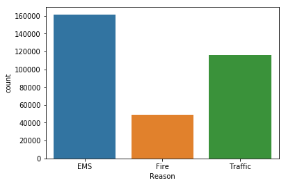

```python
sns.countplot(x='Reason',data=df);
```

**What is the data type of the objects in the timeStamp column?**

```python
type(df['Reason'][0])
```

```
str
```

**Use [pd.to_datetime](http://pandas.pydata.org/pandas-docs/stable/generated/pandas.to_datetime.html) to convert the column from strings to DateTime objects.**

```python
df['timeStamp'] = pd.to_datetime(df['timeStamp'])
type(df['timeStamp'].iloc[0])
```

```
pandas._libs.tslibs.timestamps.Timestamp
```

**We can grab specific attributes from a Datetime object like -**

```
time = df['timeStamp'].iloc[0]
time.hour
```

**Use .apply() Method, to create 3 new columns called Hour, Month, and Day of Week. You will create these columns based off the timeStamp column.**

```python
df['Hour'] = df['timeStamp'].apply(lambda time: time.hour)
df['Month'] = df['timeStamp'].apply(lambda time: time.month)
df['Day of Week'] = df['timeStamp'].apply(lambda time: time.dayofweek)
df.head()
```

|  | lat | lng | desc | zip | title | timeStamp | twp | addr | e | Reason | Hour | Month | Day of Week |
| --- | --- | --- | --- | --- | --- | --- | --- | --- | --- | --- | --- | --- | --- |
| 0 | 40.297876 | -75.581294 | REINDEER CT & DEAD END; NEW HANOVER; Station ... | 19525.0 | EMS: BACK PAINS/INJURY | 2015-12-10 17:10:52 | NEW HANOVER | REINDEER CT & DEAD END | 1 | EMS | 17 | 12 | 3 |
| 1 | 40.258061 | -75.264680 | BRIAR PATH & WHITEMARSH LN; HATFIELD TOWNSHIP... | 19446.0 | EMS: DIABETIC EMERGENCY | 2015-12-10 17:29:21 | HATFIELD TOWNSHIP | BRIAR PATH & WHITEMARSH LN | 1 | EMS | 17 | 12 | 3 |
| 2 | 40.121182 | -75.351975 | HAWS AVE; NORRISTOWN; 2015-12-10 @ 14:39:21-St... | 19401.0 | Fire: GAS-ODOR/LEAK | 2015-12-10 14:39:21 | NORRISTOWN | HAWS AVE | 1 | Fire | 14 | 12 | 3 |
| 3 | 40.116153 | -75.343513 | AIRY ST & SWEDE ST; NORRISTOWN; Station 308A;... | 19401.0 | EMS: CARDIAC EMERGENCY | 2015-12-10 16:47:36 | NORRISTOWN | AIRY ST & SWEDE ST | 1 | EMS | 16 | 12 | 3 |
| 4 | 40.251492 | -75.603350 | CHERRYWOOD CT & DEAD END; LOWER POTTSGROVE; S... | NaN | EMS: DIZZINESS | 2015-12-10 16:56:52 | LOWER POTTSGROVE | CHERRYWOOD CT & DEAD END | 1 | EMS | 16 | 12 | 3 |

**Day of Week is an integer 0-6. Use the .map() with this dictionary to map the actual string names to the day of the week:**

```
dmap = {0:'Mon',1:'Tue',2:'Wed',3:'Thu',4:'Fri',5:'Sat',6:'Sun'}
```

```python
dmap = {0:'Mon',1:'Tue',2:'Wed',3:'Thu',4:'Fri',5:'Sat',6:'Sun'}
df['Day of Week'] = df['Day of Week'].map(dmap)
df.head()
```

|  | lat | lng | desc | zip | title | timeStamp | twp | addr | e | Reason | Hour | Month | Day of Week |
| --- | --- | --- | --- | --- | --- | --- | --- | --- | --- | --- | --- | --- | --- |
| 0 | 40.297876 | -75.581294 | REINDEER CT & DEAD END; NEW HANOVER; Station ... | 19525.0 | EMS: BACK PAINS/INJURY | 2015-12-10 17:10:52 | NEW HANOVER | REINDEER CT & DEAD END | 1 | EMS | 17 | 12 | Thu |
| 1 | 40.258061 | -75.264680 | BRIAR PATH & WHITEMARSH LN; HATFIELD TOWNSHIP... | 19446.0 | EMS: DIABETIC EMERGENCY | 2015-12-10 17:29:21 | HATFIELD TOWNSHIP | BRIAR PATH & WHITEMARSH LN | 1 | EMS | 17 | 12 | Thu |
| 2 | 40.121182 | -75.351975 | HAWS AVE; NORRISTOWN; 2015-12-10 @ 14:39:21-St... | 19401.0 | Fire: GAS-ODOR/LEAK | 2015-12-10 14:39:21 | NORRISTOWN | HAWS AVE | 1 | Fire | 14 | 12 | Thu |
| 3 | 40.116153 | -75.343513 | AIRY ST & SWEDE ST; NORRISTOWN; Station 308A;... | 19401.0 | EMS: CARDIAC EMERGENCY | 2015-12-10 16:47:36 | NORRISTOWN | AIRY ST & SWEDE ST | 1 | EMS | 16 | 12 | Thu |
| 4 | 40.251492 | -75.603350 | CHERRYWOOD CT & DEAD END; LOWER POTTSGROVE; S... | NaN | EMS: DIZZINESS | 2015-12-10 16:56:52 | LOWER POTTSGROVE | CHERRYWOOD CT & DEAD END | 1 | EMS | 16 | 12 | Thu |

**Use seaborn to create a countplot of the Day of Week column with the hue based off of the Reason column.**

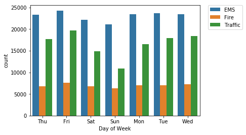

```python
sns.countplot(x='Day of Week',data=df, hue ='Reason')
# Relocation of the legends outside
plt.legend(bbox_to_anchor=(1.05,1),loc=2,borderaxespad=0.);
```

**Now do the same for Month:**

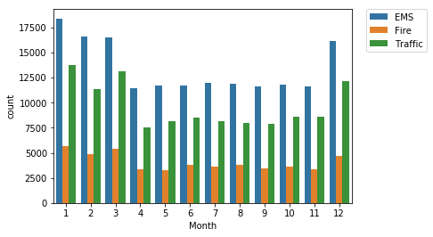

```python
sns.countplot(x='Month',data=df, hue ='Reason')
# Relocation of the legends outside
plt.legend(bbox_to_anchor=(1.05,1),loc=2,borderaxespad=0.);
```

**Create a new column called 'Date' that contains the date from the timeStamp column. You'll need to use apply along with the .date() method.**

```python
df['Date'] = df['timeStamp'].apply(lambda t: t.date())
df.head()
```

|  | lat | lng | desc | zip | title | timeStamp | twp | addr | e | Reason | Hour | Month | Day of Week | Date |
| --- | --- | --- | --- | --- | --- | --- | --- | --- | --- | --- | --- | --- | --- | --- |
| 0 | 40.297876 | -75.581294 | REINDEER CT & DEAD END; NEW HANOVER; Station ... | 19525.0 | EMS: BACK PAINS/INJURY | 2015-12-10 17:10:52 | NEW HANOVER | REINDEER CT & DEAD END | 1 | EMS | 17 | 12 | Thu | 2015-12-10 |
| 1 | 40.258061 | -75.264680 | BRIAR PATH & WHITEMARSH LN; HATFIELD TOWNSHIP... | 19446.0 | EMS: DIABETIC EMERGENCY | 2015-12-10 17:29:21 | HATFIELD TOWNSHIP | BRIAR PATH & WHITEMARSH LN | 1 | EMS | 17 | 12 | Thu | 2015-12-10 |
| 2 | 40.121182 | -75.351975 | HAWS AVE; NORRISTOWN; 2015-12-10 @ 14:39:21-St... | 19401.0 | Fire: GAS-ODOR/LEAK | 2015-12-10 14:39:21 | NORRISTOWN | HAWS AVE | 1 | Fire | 14 | 12 | Thu | 2015-12-10 |
| 3 | 40.116153 | -75.343513 | AIRY ST & SWEDE ST; NORRISTOWN; Station 308A;... | 19401.0 | EMS: CARDIAC EMERGENCY | 2015-12-10 16:47:36 | NORRISTOWN | AIRY ST & SWEDE ST | 1 | EMS | 16 | 12 | Thu | 2015-12-10 |
| 4 | 40.251492 | -75.603350 | CHERRYWOOD CT & DEAD END; LOWER POTTSGROVE; S... | NaN | EMS: DIZZINESS | 2015-12-10 16:56:52 | LOWER POTTSGROVE | CHERRYWOOD CT & DEAD END | 1 | EMS | 16 | 12 | Thu | 2015-12-10 |

**Now groupby this Date column with the count() aggregate and create a plot of counts of 911 calls.**

```python
df.groupby('Date').count()
```

| Date | lat | lng | desc | zip | title | timeStamp | twp | addr | e | Reason | Hour | Month | Day of Week |
| --- | --- | --- | --- | --- | --- | --- | --- | --- | --- | --- | --- | --- | --- |
| 2015-12-10 | 114 | 114 | 114 | 100 | 114 | 114 | 114 | 114 | 114 | 114 | 114 | 114 | 114 |
| 2015-12-11 | 391 | 391 | 391 | 332 | 391 | 391 | 391 | 391 | 391 | 391 | 391 | 391 | 391 |
| 2015-12-12 | 402 | 402 | 402 | 334 | 402 | 402 | 402 | 402 | 402 | 402 | 402 | 402 | 402 |
| 2015-12-13 | 316 | 316 | 316 | 279 | 316 | 316 | 316 | 316 | 316 | 316 | 316 | 316 | 316 |
| 2015-12-14 | 444 | 444 | 444 | 386 | 444 | 444 | 443 | 444 | 444 | 444 | 444 | 444 | 444 |
| 2015-12-15 | 419 | 419 | 419 | 380 | 419 | 419 | 418 | 419 | 419 | 419 | 419 | 419 | 419 |
| 2015-12-16 | 376 | 376 | 376 | 343 | 376 | 376 | 376 | 376 | 376 | 376 | 376 | 376 | 376 |
| 2015-12-17 | 387 | 387 | 387 | 336 | 387 | 387 | 387 | 387 | 387 | 387 | 387 | 387 | 387 |
| 2015-12-18 | 346 | 346 | 346 | 306 | 346 | 346 | 346 | 346 | 346 | 346 | 346 | 346 | 346 |
| 2015-12-19 | 272 | 272 | 272 | 239 | 272 | 272 | 272 | 272 | 272 | 272 | 272 | 272 | 272 |
| 2015-12-20 | 271 | 271 | 271 | 236 | 271 | 271 | 271 | 271 | 271 | 271 | 271 | 271 | 271 |
| 2015-12-21 | 427 | 427 | 427 | 376 | 427 | 427 | 427 | 427 | 427 | 427 | 427 | 427 | 427 |
| 2015-12-22 | 448 | 448 | 448 | 399 | 448 | 448 | 448 | 448 | 448 | 448 | 448 | 448 | 448 |
| 2015-12-23 | 519 | 519 | 519 | 430 | 519 | 519 | 519 | 519 | 519 | 519 | 519 | 519 | 519 |
| 2015-12-24 | 447 | 447 | 447 | 387 | 447 | 447 | 446 | 447 | 447 | 447 | 447 | 447 | 447 |
| 2015-12-25 | 321 | 321 | 321 | 266 | 321 | 321 | 321 | 321 | 321 | 321 | 321 | 321 | 321 |
| 2015-12-26 | 286 | 286 | 286 | 258 | 286 | 286 | 286 | 286 | 286 | 286 | 286 | 286 | 286 |
| 2015-12-27 | 317 | 317 | 317 | 290 | 317 | 317 | 317 | 317 | 317 | 317 | 317 | 317 | 317 |
| 2015-12-28 | 380 | 380 | 380 | 337 | 380 | 380 | 380 | 380 | 380 | 380 | 380 | 380 | 380 |
| 2015-12-29 | 367 | 367 | 367 | 315 | 367 | 367 | 367 | 367 | 367 | 367 | 367 | 367 | 367 |
| 2015-12-30 | 352 | 352 | 352 | 305 | 352 | 352 | 350 | 352 | 352 | 352 | 352 | 352 | 352 |
| 2015-12-31 | 314 | 314 | 314 | 268 | 314 | 314 | 314 | 314 | 314 | 314 | 314 | 314 | 314 |
| 2016-01-01 | 262 | 262 | 262 | 236 | 262 | 262 | 262 | 262 | 262 | 262 | 262 | 262 | 262 |
| 2016-01-02 | 334 | 334 | 334 | 300 | 334 | 334 | 333 | 334 | 334 | 334 | 334 | 334 | 334 |
| 2016-01-03 | 322 | 322 | 322 | 284 | 322 | 322 | 322 | 322 | 322 | 322 | 322 | 322 | 322 |
| 2016-01-04 | 401 | 401 | 401 | 345 | 401 | 401 | 401 | 401 | 401 | 401 | 401 | 401 | 401 |
| 2016-01-05 | 445 | 445 | 445 | 373 | 445 | 445 | 445 | 445 | 445 | 445 | 445 | 445 | 445 |
| 2016-01-06 | 430 | 430 | 430 | 375 | 430 | 430 | 429 | 430 | 430 | 430 | 430 | 430 | 430 |
| 2016-01-07 | 385 | 385 | 385 | 334 | 385 | 385 | 385 | 385 | 385 | 385 | 385 | 385 | 385 |
| 2016-01-08 | 359 | 359 | 359 | 326 | 359 | 359 | 359 | 359 | 359 | 359 | 359 | 359 | 359 |
| ... | ... | ... | ... | ... | ... | ... | ... | ... | ... | ... | ... | ... | ... |
| 2018-02-23 | 409 | 409 | 409 | 373 | 409 | 409 | 409 | 409 | 409 | 409 | 409 | 409 | 409 |
| 2018-02-24 | 350 | 350 | 350 | 299 | 350 | 350 | 349 | 350 | 350 | 350 | 350 | 350 | 350 |
| 2018-02-25 | 328 | 328 | 328 | 303 | 328 | 328 | 328 | 328 | 328 | 328 | 328 | 328 | 328 |
| 2018-02-26 | 396 | 396 | 396 | 339 | 396 | 396 | 396 | 396 | 396 | 396 | 396 | 396 | 396 |
| 2018-02-27 | 403 | 403 | 403 | 360 | 403 | 403 | 403 | 403 | 403 | 403 | 403 | 403 | 403 |
| 2018-02-28 | 364 | 364 | 364 | 323 | 364 | 364 | 364 | 364 | 364 | 364 | 364 | 364 | 364 |
| 2018-03-01 | 396 | 396 | 396 | 354 | 396 | 396 | 396 | 396 | 396 | 396 | 396 | 396 | 396 |
| 2018-03-02 | 2187 | 2187 | 2187 | 1986 | 2187 | 2187 | 2187 | 2187 | 2187 | 2187 | 2187 | 2187 | 2187 |
| 2018-03-03 | 917 | 917 | 917 | 836 | 917 | 917 | 917 | 917 | 917 | 917 | 917 | 917 | 917 |
| 2018-03-04 | 412 | 412 | 412 | 369 | 412 | 412 | 412 | 412 | 412 | 412 | 412 | 412 | 412 |
| 2018-03-05 | 484 | 484 | 484 | 439 | 484 | 484 | 484 | 484 | 484 | 484 | 484 | 484 | 484 |
| 2018-03-06 | 456 | 456 | 456 | 397 | 456 | 456 | 455 | 456 | 456 | 456 | 456 | 456 | 456 |
| 2018-03-07 | 920 | 920 | 920 | 824 | 920 | 920 | 920 | 920 | 920 | 920 | 920 | 920 | 920 |
| 2018-03-08 | 499 | 499 | 499 | 449 | 499 | 499 | 499 | 499 | 499 | 499 | 499 | 499 | 499 |
| 2018-03-09 | 439 | 439 | 439 | 396 | 439 | 439 | 439 | 439 | 439 | 439 | 439 | 439 | 439 |
| 2018-03-10 | 395 | 395 | 395 | 353 | 395 | 395 | 395 | 395 | 395 | 395 | 395 | 395 | 395 |
| 2018-03-11 | 309 | 309 | 309 | 266 | 309 | 309 | 309 | 309 | 309 | 309 | 309 | 309 | 309 |
| 2018-03-12 | 340 | 340 | 340 | 293 | 340 | 340 | 340 | 340 | 340 | 340 | 340 | 340 | 340 |
| 2018-03-13 | 370 | 370 | 370 | 319 | 370 | 370 | 370 | 370 | 370 | 370 | 370 | 370 | 370 |
| 2018-03-14 | 387 | 387 | 387 | 343 | 387 | 387 | 387 | 387 | 387 | 387 | 387 | 387 | 387 |
| 2018-03-15 | 377 | 377 | 377 | 340 | 377 | 377 | 377 | 377 | 377 | 377 | 377 | 377 | 377 |
| 2018-03-16 | 433 | 433 | 433 | 380 | 433 | 433 | 433 | 433 | 433 | 433 | 433 | 433 | 433 |
| 2018-03-17 | 322 | 322 | 322 | 291 | 322 | 322 | 322 | 322 | 322 | 322 | 322 | 322 | 322 |
| 2018-03-18 | 318 | 318 | 318 | 277 | 318 | 318 | 318 | 318 | 318 | 318 | 318 | 318 | 318 |
| 2018-03-19 | 386 | 386 | 386 | 341 | 386 | 386 | 386 | 386 | 386 | 386 | 386 | 386 | 386 |
| 2018-03-20 | 397 | 397 | 397 | 322 | 397 | 397 | 397 | 397 | 397 | 397 | 397 | 397 | 397 |
| 2018-03-21 | 484 | 484 | 484 | 427 | 484 | 484 | 484 | 484 | 484 | 484 | 484 | 484 | 484 |
| 2018-03-22 | 420 | 420 | 420 | 370 | 420 | 420 | 420 | 420 | 420 | 420 | 420 | 420 | 420 |
| 2018-03-23 | 414 | 414 | 414 | 373 | 414 | 414 | 412 | 414 | 414 | 414 | 414 | 414 | 414 |
| 2018-03-24 | 182 | 182 | 182 | 165 | 182 | 182 | 182 | 182 | 182 | 182 | 182 | 182 | 182 |

835 rows × 13 columns

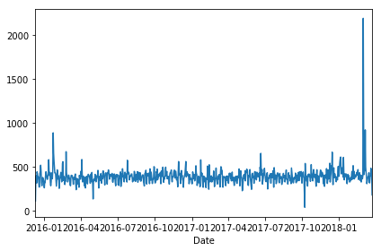

```python
df.groupby('Date').count()['lat'].plot()
plt.tight_layout()
```

**Now recreate this plot but create 3 separate plots with each plot representing a Reason for the 911 call**

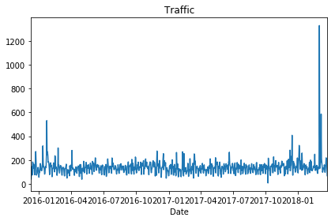

```python
df[df['Reason']=='Traffic'].groupby('Date').count()['lat'].plot()
plt.title("Traffic")
plt.tight_layout()
```

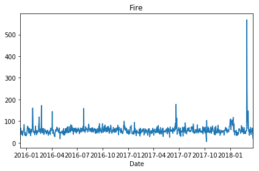

```python
df[df['Reason']=='Fire'].groupby('Date').count()['lat'].plot()
plt.title("Fire")
plt.tight_layout()
```

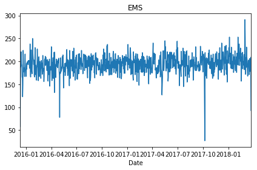

```python
df[df['Reason']=='EMS'].groupby('Date').count()['lat'].plot()
plt.title("EMS")
plt.tight_layout()
```

**Let's try to create heatmaps with seaborn and our data. But, first we will need to restructure the dataframe so that the columns become the Hours and the Index becomes the Day of the Week. There are lots of ways to do this, but let's try to combine groupby with an [unstack](http://pandas.pydata.org/pandas-docs/stable/generated/pandas.DataFrame.unstack.html) method.**

```python
dayHour = df.groupby(by=['Day of Week','Hour']).count()['Reason'].unstack() ##Here, we can also use pivot method
```

```python
dayHour.head()
```

| Hour Day of Week | 0 | 1 | 2 | 3 | 4 | 5 | 6 | 7 | 8 | 9 | ... | 14 | 15 | 16 | 17 | 18 | 19 | 20 | 21 | 22 | 23 |
| --- | --- | --- | --- | --- | --- | --- | --- | --- | --- | --- | --- | --- | --- | --- | --- | --- | --- | --- | --- | --- | --- |
| Fri | 896 | 789 | 701 | 644 | 633 | 786 | 1286 | 2087 | 2487 | 2570 | ... | 3290 | 3562 | 3726 | 3596 | 2858 | 2562 | 2205 | 1916 | 1765 | 1396 |
| Mon | 931 | 732 | 663 | 585 | 683 | 862 | 1291 | 2175 | 2714 | 2766 | ... | 2729 | 3034 | 3082 | 3116 | 2729 | 2179 | 1912 | 1503 | 1303 | 1003 |
| Sat | 1130 | 999 | 908 | 767 | 742 | 788 | 957 | 1295 | 1674 | 2132 | ... | 2643 | 2563 | 2529 | 2525 | 2477 | 2320 | 2074 | 1839 | 1579 | 1469 |
| Sun | 1159 | 1026 | 955 | 800 | 717 | 736 | 880 | 1196 | 1492 | 1849 | ... | 2276 | 2170 | 2200 | 2234 | 2179 | 2067 | 1753 | 1536 | 1235 | 1177 |
| Thu | 871 | 690 | 727 | 603 | 573 | 833 | 1386 | 2254 | 2613 | 2719 | ... | 2863 | 3044 | 3017 | 3335 | 2707 | 2226 | 1974 | 1724 | 1360 | 1120 |

5 rows × 24 columns

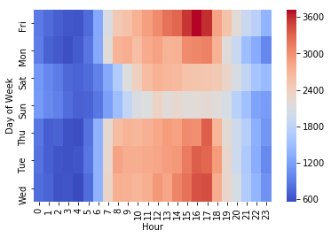

```python
sns.heatmap(dayHour,cmap='coolwarm');
```

**Now create a clustermap using this DataFrame.**

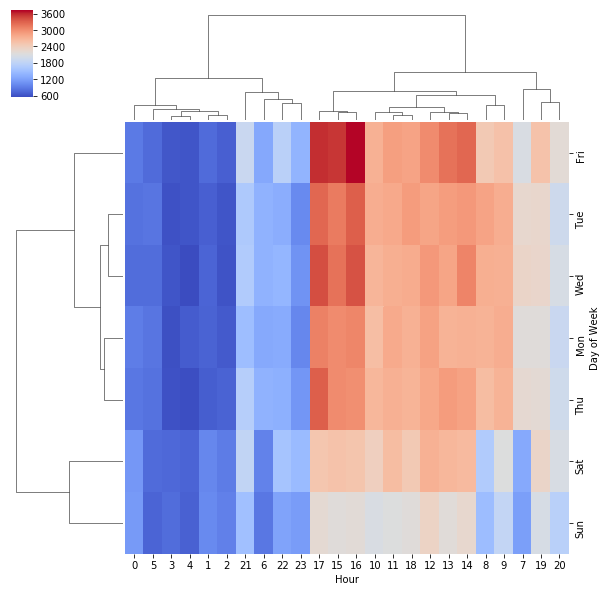

```python
sns.clustermap(dayHour,cmap='coolwarm');
```

**Now repeat these same plots and operations, for a DataFrame that shows the Month as the column.**

```python
dayMonth = df.groupby(by=['Day of Week','Month']).count()['Reason'].unstack()
dayMonth.head()
```

| Month Day of Week | 1 | 2 | 3 | 4 | 5 | 6 | 7 | 8 | 9 | 10 | 11 | 12 |
| --- | --- | --- | --- | --- | --- | --- | --- | --- | --- | --- | --- | --- |
| Fri | 5532 | 4848 | 7005 | 3574 | 3278 | 3747 | 3736 | 3297 | 4226 | 3433 | 3377 | 5570 |
| Mon | 5716 | 5214 | 4313 | 3088 | 3538 | 3264 | 3687 | 3325 | 3031 | 4250 | 3262 | 4286 |
| Sat | 5103 | 4431 | 4355 | 3490 | 2764 | 3024 | 3515 | 2810 | 3144 | 3042 | 2972 | 5200 |
| Sun | 4882 | 3806 | 3268 | 3026 | 2580 | 2679 | 3259 | 2658 | 2565 | 3172 | 2592 | 3896 |
| Thu | 4985 | 4708 | 5601 | 3097 | 3289 | 4095 | 3248 | 3507 | 3702 | 3189 | 3478 | 4899 |

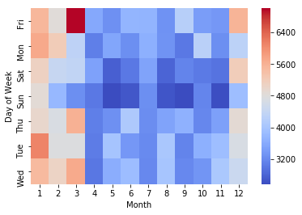

```python
sns.heatmap(dayMonth,cmap='coolwarm');
```

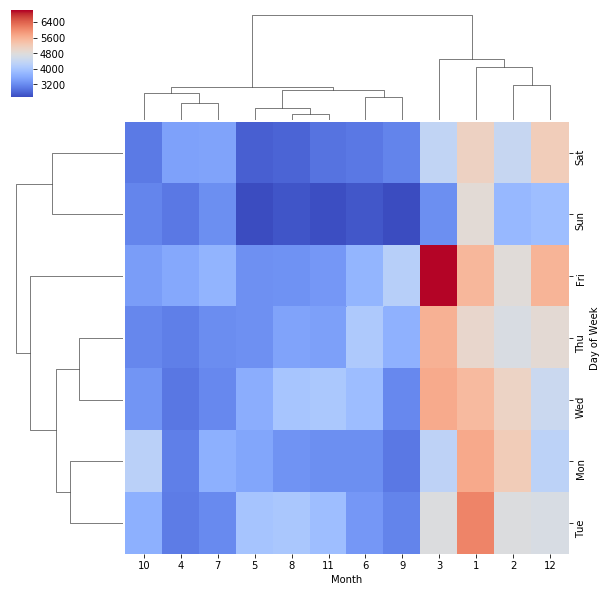

```python
sns.clustermap(dayMonth,cmap='coolwarm');
```